# #3 Philadelphia household travel survey

Minwook Kang

2022-10-06

```r
# Rmarkdown global setting
knitr::opts_chunk$set(echo = TRUE)
knitr::opts_chunk$set(message = FALSE)
knitr::opts_chunk$set(warning = FALSE)
knitr::opts_chunk$set(cache = TRUE)
knitr::opts_chunk$set(fig.align = 'center')

# Import libraries
library(RCurl)
library(tidyverse)
library(dplyr)
library(kableExtra)
library(ggpubr)

# Import Raw Data
hh <- getURL("https://raw.githubusercontent.com/kmu973/ITRP/main/1_Household_Public.csv")
hh <- read.csv(text = hh)
per <- getURL("https://raw.githubusercontent.com/kmu973/ITRP/main/2_Person_Public.csv")
per <- read.csv(text = per)
veh <- getURL("https://raw.githubusercontent.com/kmu973/ITRP/main/3_Vehicle_Public.csv")
veh <- read.csv(text = veh)
trip <- getURL("https://raw.githubusercontent.com/kmu973/ITRP/main/4_Trip_Public.csv")
trip <- read.csv(text = trip)
```

## Q1

##### Draw a random household from the second ten households in your data. If your data frame is named dat, this command will do it for you: sort(unique(dat$HH_ID))[sample(11:20, 1)] Write a **brief description of the household**. Be sure to include: their income, race, composition, county of residence, and whether they own a car.

All 10 House Holds selected as samples are located in Burlington County, and Race could not be confirmed. Since owning a vehicle is considered to have one or more vehicles regardless of income, **it is highly likely that their daily life is almost impossible without a vehicle.**

```r
set.seed(200)

Q1 <- data.frame(HH_ID = sort(unique(hh$HH_ID))[sample(11:20)]) %>%
  left_join(hh, by = "HH_ID") %>%
  left_join(per, by = "HH_ID") %>%
  left_join(veh, by = "HH_ID") %>%
  dplyr::select( HouseHold_ID = HH_ID, Income = INCOME, Race = RACE, HouseHoldSize = HH_SIZE, HouseHoldCounty = H_COUNTY, TotalVehicleNumber = TOT_VEH.x)%>%
  distinct()%>%
  arrange(Income)%>%
  mutate(Income = case_when(Income == 1 ~ "0 to 9,999",
                            Income == 2 ~ "10,000 to 24,999",
                            Income == 3 ~ "25,000 to 34,999",
                            Income == 4 ~ "35,000 to 49,999",
                            Income == 5 ~ "50,000 to 74,999",
                            Income == 6 ~ "75,000 to 99,999",
                            Income == 7 ~ "100,000 to 149,999",
                            Income == 8 ~ "150,000 to 199,999",
                            Income == 9 ~ "200,000 to 249,999",
                            Income == 10 ~ "250,000 more"
                            ),
         HouseHoldCounty = case_when(HouseHoldCounty == 34005 ~ "Burlington"))

opts <- options(knitr.kable.NA = "Unknown")

Q1 %>% kable(caption = "Table1. Description of Household", align = "c") %>%
  kable_classic(full_width = T, html_font = "Cambria", font_size = 15) %>%
  row_spec(0, bold = T) %>%
  footnote(general = "", fixed_small_size = T, general_title = "")
```

Table1. Description of Household

| HouseHold_ID | Income | Race | HouseHoldSize | HouseHoldCounty | TotalVehicleNumber |
| --- | --- | --- | --- | --- | --- |
| 101175 | 10,000 to 24,999 | 988 | 1 | Burlington | 1 |
| 101057 | 35,000 to 49,999 | 988 | 1 | Burlington | 1 |
| 101182 | 50,000 to 74,999 | 988 | 2 | Burlington | 2 |
| 101191 | 50,000 to 74,999 | 988 | 2 | Burlington | 3 |
| 101162 | 50,000 to 74,999 | 988 | 1 | Burlington | 1 |
| 101113 | 75,000 to 99,999 | 988 | 1 | Burlington | 1 |
| 101258 | 100,000 to 149,999 | 988 | 2 | Burlington | 1 |
| 100702 | 100,000 to 149,999 | 988 | 2 | Burlington | 2 |
| 101256 | 100,000 to 149,999 | 988 | 3 | Burlington | 2 |
| 101096 | Unknown | 988 | 3 | Burlington | 4 |

## Q2

##### Describe the **daily activities and travel** of the household’s members using the trip data

```r
Q2 <- trip %>%
  dplyr::filter(HH_ID == "100140", PERSON_ID == "10014001")%>%
  select(HouseHold_ID = HH_ID, TourType = TOUR_TYPE, Location = O_LOC_TYPE, Mode =  MODE_AGG, Arrival = ARRIVE, Departure = DEPART, ActivityType = ACTIV1, ActivityDuration = ACT_DUR1) %>%
  mutate(TourType = case_when(TourType == 1 ~ "Home:work"),
         Location = case_when(Location == 1 ~ "Home",
                              Location == 4 ~ "Other"),
         Mode = case_when(Mode == 3 ~ "Private Vehicle"),
         ActivityType = case_when(ActivityType == 1 ~ "Home activities",
                                  ActivityType == 6 ~ "Personal business",
                                  ActivityType == 8 ~ "Everyday shopping"))


opts <- options(knitr.kable.NA = " ")

Q2 %>% kable(caption = "Table2. Daily Activities and Travel", align = "c") %>%
  kable_classic(full_width = T, html_font = "Cambria", font_size = 15) %>%
  row_spec(0, bold = T) %>%
  footnote(general = "", fixed_small_size = T, general_title = "")
```

Table2. Daily Activities and Travel

| HouseHold_ID | TourType | Location | Mode | Arrival | Departure | ActivityType | ActivityDuration |
| --- | --- | --- | --- | --- | --- | --- | --- |
| 100140 | Home:work | Home | Private Vehicle |  | 11:00 | Home activities | 2:00 |
| 100140 | Home:work | Other | Private Vehicle | 11:15 | 11:30 | Personal business | 0:15 |
| 100140 | Home:work | Other | Private Vehicle | 11:37 | 12:07 | Everyday shopping | 0:30 |
| 100140 | Home:work | Other | Private Vehicle | 12:19 | 12:34 | Everyday shopping | 0:15 |
| 100140 | Home:work | Other | Private Vehicle | 12:50 | 13:10 | Everyday shopping | 0:20 |
| 100140 |  | Home |  | 13:20 |  | Home activities | 10:30 |

## Q3

##### Provide an estimate of **the total number of bicycle trips** represented by the survey data. Note that you should use the Person Weight to make this estimate. This number represents the total number of people each person in the survey is supposed to represent. For example, if a person’s Person Weight is 65, then that person represents 65 people in the Philadelphia region.

```r
Q3 %>% kable(caption = "Table3. Total Bycicle Trips", align = "c") %>%
  kable_classic(full_width = T, html_font = "Cambria", font_size = 15) %>%
  row_spec(0, bold = T) %>%
  footnote(general = "", fixed_small_size = T, general_title = "")
```

Table3. Total Bycicle Trips

| TotalBicycleTrip |
| --- |
| 143641.9 |

## Q4

##### Make a table that shows **the mode choice for residents** from the county of the household from question 1. Note that you will have to make a choice about how to group the modes together. Note also that I asked for the home county not the origin of a trip county. Look for this in the data dictionary.

The County of House Hold used in Question 1 is Burlington. Using the aggregate of transportation modes, 88.28% of Trip corresponds to a private vehicle, and it can be seen that it is a county with little Transit.

```r
#34005

Q4 <- trip %>%
  left_join(hh, by = "HH_ID") %>%
  dplyr::filter(H_COUNTY == "34005")%>%
  select(HH_ID, MODE_AGG) %>%
  na.omit() %>%
  group_by(MODE_AGG) %>%
  summarise(Total = n())%>%
  mutate(Share = round(Total / sum(Total)*100,2))%>%
  select(-Total) %>%
  spread(MODE_AGG, Share) %>%
  rename(Walk = 1, Bike = 2, PrivateVehicle =3, PrivateTransit =4, PublicTransit =5, SchoolBus =6, Other=7)

opts <- options(knitr.kable.NA = " - ")

Q4 %>% kable(caption = "Table4. Mode share of Burlington county", align = "c") %>%
  kable_classic(full_width = T, html_font = "Cambria", font_size = 15) %>%
  row_spec(0, bold = T) %>%
  footnote(general = "", fixed_small_size = T, general_title = "")
```

Table4. Mode share of Burlington county

| Walk | Bike | PrivateVehicle | PrivateTransit | PublicTransit | SchoolBus | Other |
| --- | --- | --- | --- | --- | --- | --- |
| 4.33 | 0.39 | 88.28 | 0.39 | 2.83 | 3.46 | 0.33 |

## Q5

##### Make a graphic that shows the relationship between **household income** and **the age of a household’s vehicle** for all households. (Hint: merge the household data to the vehicle data with the merge() command. Use an internet search or type ?merge into the console to learn how to use the command.)

Figure 1. is a Violin Chart was drawn using Household Income and Household Vehicle Age. Since the Income data is Category Data, it is difficult to visualize the data by using Scatter Plot. On the other hand, using the Violin Chart, the Vehicle Age distribution trend for each income category could be intuitively confirmed. It was a result consistent with general common sense, the higher the income, the newer the vehicle, and the lower the income, the older the vehicle.

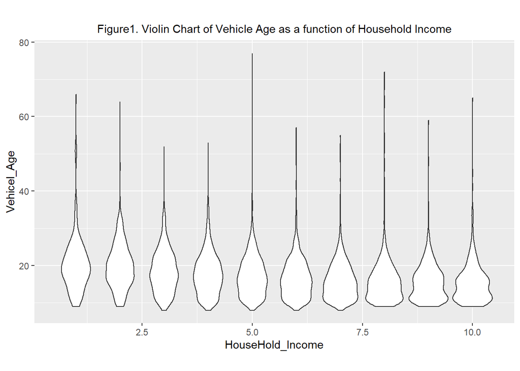

```r
#household income = hh$INCOME , the age of a household’s vehicle = veh$Year

Q5 <- hh %>%
  left_join(veh, by = "HH_ID")%>%
  select(HH_ID, INCOME, YEAR) %>%
  filter(INCOME < 80, YEAR < 8000 ) %>%
  mutate(AGE = 2022-YEAR) %>%
  select(Vehicel_Age = AGE,  HouseHold_Income = INCOME)

#str(Q5)

P1 <- ggplot(Q5) +
  geom_point(aes(x=HouseHold_Income, y=Vehicel_Age), size = 0.6)

P3 <-ggplot(Q5, aes(HouseHold_Income, Vehicel_Age)) +
  geom_violin(aes(group = cut_width(HouseHold_Income, 1))) +
  labs(title="",
       subtitle="Figure1. Violin Chart of Vehicle Age as a function of Household Income",
       caption="") +
  theme(plot.subtitle = element_text(hjust = 0.5))


P2 <- ggplot(Q5, aes(HouseHold_Income, Vehicel_Age)) +
  geom_jitter(height = 0.5, width = 0.5, size = 0.4, alpha = 0.5)

#ggarrange(P1,P2,P3)

P3
```

## Q6

##### Make a table or graphic that shows the relationship between household income and mode choice for all households. (The boxplot() command is a nice option, but a table is just fine.) Again, you must choose how to combine modes.

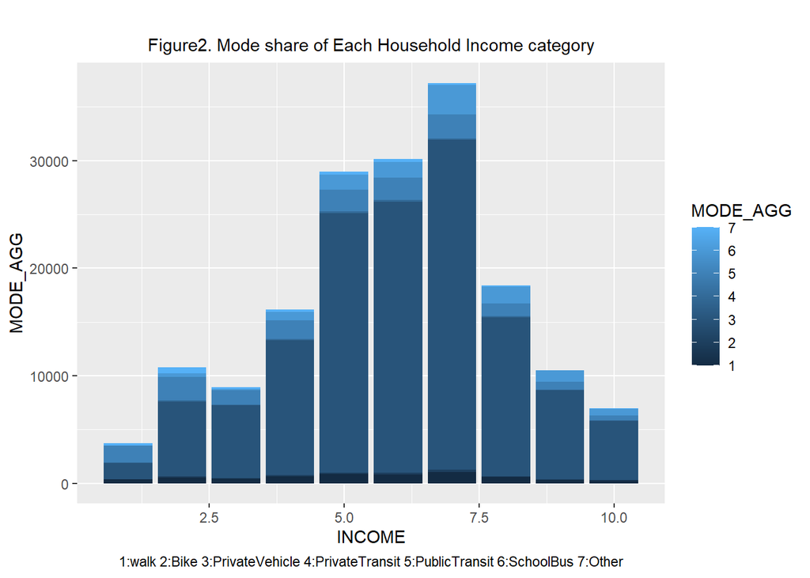

```r
Q6 <- trip %>%
  left_join(hh, by = "HH_ID")%>%
  select(HH_ID, INCOME, MODE_AGG)%>%
  filter(INCOME < 80)%>%
  na.omit() %>%
  arrange(MODE_AGG)


#str(Q6)

#Walk = 1, Bike = 2, PrivateVehicle =3, PrivateTransit =4, PublicTransit =5, SchoolBus =6, Other=7

ggplot(Q6, aes(x = INCOME, y = MODE_AGG, fill = MODE_AGG)) +
  geom_col() +
  labs(title="",
       subtitle="Figure2. Mode share of Each Household Income category",
       caption="1:walk 2:Bike 3:PrivateVehicle 4:PrivateTransit 5:PublicTransit 6:SchoolBus 7:Other")+
  theme(plot.subtitle = element_text(hjust = 0.5), plot.caption = element_text(hjust = 0.5))
```

## Q7

##### a. According to the regression model, each additional job within a half mile of a station correlates with how many more daily transit riders per day?

According to the Regression model, each time the Job with a half mile increases by one unit, an additional 0.179 rail leadership increases.

##### b. If there are an average of 1,793 boardings per station and 3,130 jobs around each station, what percentage increase in ridership does the model predict due to a doubling of the number of jobs around a station (hint: elasticity).

According to the assumption above, a total of 3,130 additional jobs will occur near each station, and according to the Regression model, this will result in an additional 560.27 passengers. As a result, percentage increase in ridership is $560.27 \div 1,793 \times 100 = 31.24(\%)$.

##### c. Describe the relationship between AM peak service frequency and light rail boardings.

According to the model, an increase in AM peak service frequency of 1 unit increases approximately 105.822 passengers.In addition, p<0.01 can reject the null hypothesis that AM peak service frequency is not related to Daily light rail boards.